# From Points to Prints

Generation of building roofprints and footprints from ALS point clouds

Alexandre Bry

abry.pro@proton.me

# Context

## Reconstruction of 3D buildings

- Many applications of 3D buildings: visualization, simulations, solar potential, etc.
- Different levels of detail required

## Levels of detail

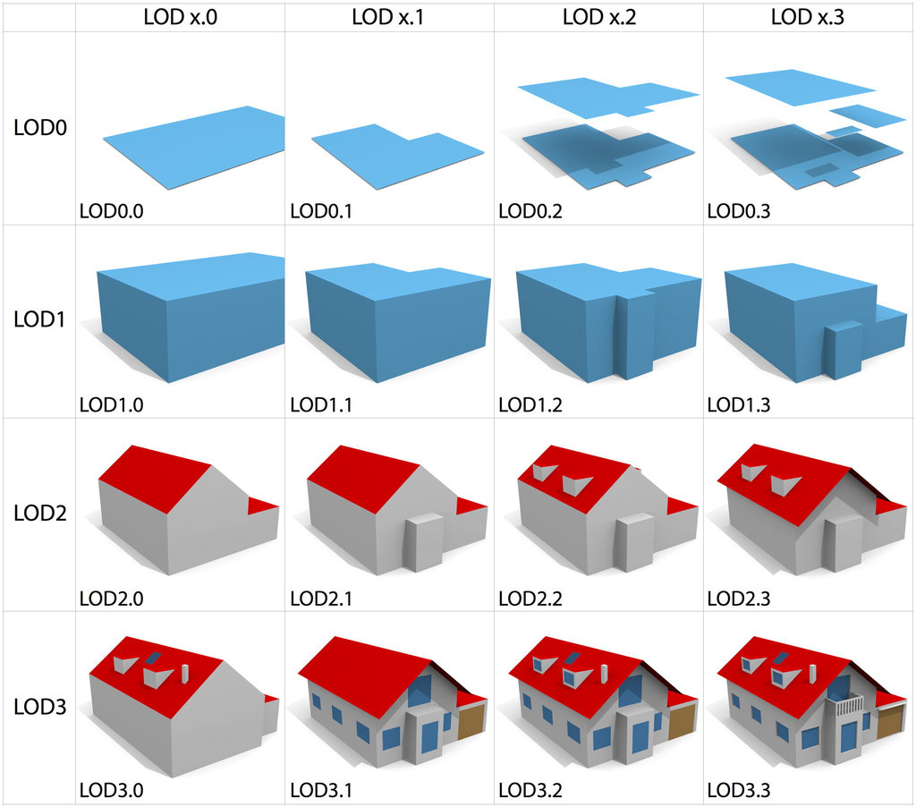

Visual example of the refined LoDs for a residential building (Biljecki et al., 2016).

## 3DBAG example

[figure not shown]

Screenshot from the [online viewer of the 3DBAG](https://3dbag.nl/en/viewer?rdx=85202.42204919437&rdy=446838.496813776&ox=-0.00010789974476210773&oy=247.78640814561538&oz=255.13012753776275).

## French context

- [BD TOPO](https://geoservices.ign.fr/bdtopo): building outlines in France
- [LiDAR HD](https://www.ign.fr/institut/programme-lidar-hd-vers-une-nouvelle-cartographie-3d-du-territoire): first nationwide ALS LiDAR dataset of France
- [Jumeau numérique de la France](https://www.ign.fr/institut/un-jumeau-numerique-de-la-france-pour-piloter-la-transition-ecologique): future digital twin of France

## What about façade points?

- ALS point clouds give high density of points on roofs and low density on façades

*What characteristics of ALS point clouds influence the ability to generate accurate building roofprints and footprints?*

# Definitions

## Building elements

Roof overhangs (eaves)

The portion of a roof that extends beyond the exterior walls of a building.

Roofprint

The vertical projection of all the roof components of a building.

Footprint

The vertical projection of the main façades of a building.

## Illustrations

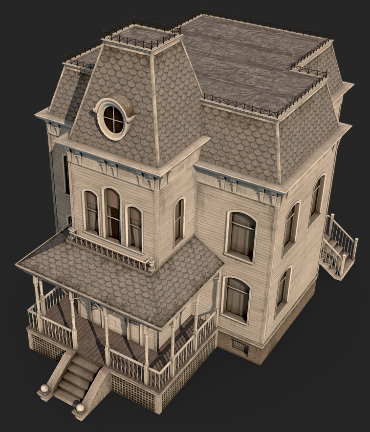

3D model from [Sketchfab](https://sketchfab.com/3d-models/haunted-house-f709acd09d9640698bfc5baa14f30fe9).

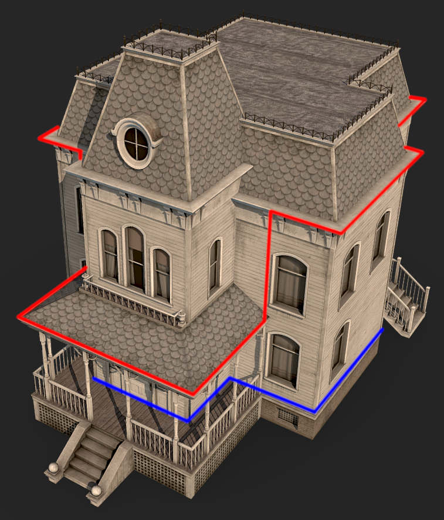

Footprint and roofprint (before vertical projection).

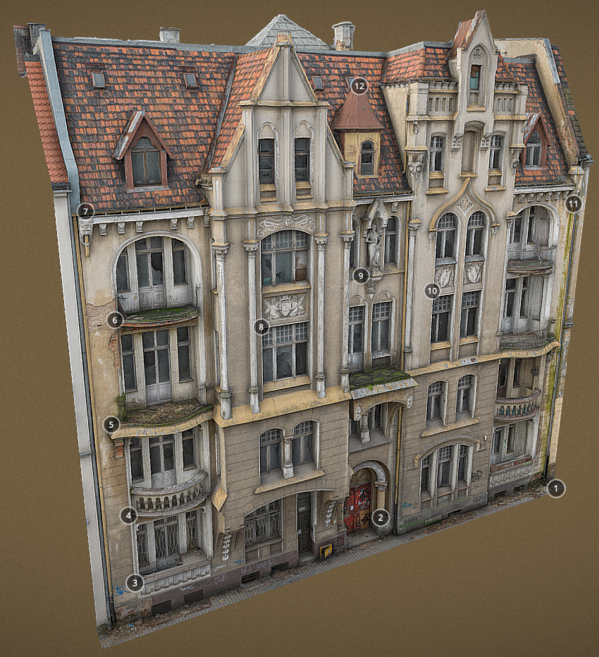

3D model from [Sketchfab](https://sketchfab.com/3d-models/facade-of-an-art-nouveau-tenement-house-01-04caebf37130491aacbd272962d96ebc).

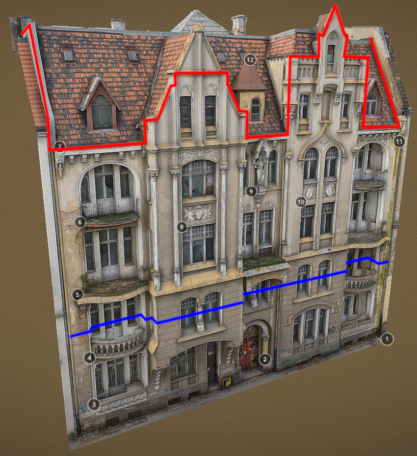

Footprint and roofprint (before vertical projection).

Figure 1: Examples of footprints (in blue) and roofprints (in red) for complex buildings.

# Research context

## Roof overhangs

- Sweeping vertical planes:
  - Using a 2.5D DSM and a footprint (Dahlke et al., 2015; Frommholz et al., 2017)
  - Using a point cloud and a roofprint (Panday & Gerke, 2012)
- Extending the roof planes (Goebbels & Pohle-Fröhlich, 2023)

## Point cloud semantic segmentation

- Range-images as input (Biasutti et al., 2019; Xu et al., 2020)
- 3D convolutions (KPConv, PointTransformerv3, etc) (W. Li et al., 2020; Thomas et al., 2019; Wu et al., 2023; Zhao et al., 2020)
- Class imbalance (M. Li et al., 2024; Pan et al., 2025)

## Datasets

Table 1: List of point cloud datasets for semantic segmentation of point clouds.

| Name | Number of points | Point density (pts/m²) | Classes for roof/façade | Source | Paper |
| --- | --- | --- | --- | --- | --- |
| H3D | 74M | 800 | Yes | ALS | Kölle et al. (2021) |
| V3D | 0.78M | 8 | Yes | ALS | Cramer (2010) Niemeyer et al. (2014) |
| DublinCity | 260M | 348 | Yes | ALS | Zolanvari et al. (2019) |
| Campus3D | 937.1M |  | Yes | Aerial images | X. Li et al. (2020) |
| CENAGIS-ALS | 550M | 275 | Yes | ALS | Zachar et al. (2023) |
| DALES | 505M | 50 | No | ALS | Varney et al. (2020) |
| SensatUrban | 2847M |  | No | Aerial images | Hu et al. (2020) |
| LASDU | 3.12M | 4 | No | ALS | Ye et al. (2020) |
| TALD | 121M | 12 | No | ALS | Vijaywargiya & Ramiya (2025) |
| FRACTAL | 9261M | 37 | No | ALS | Gaydon et al. (2024) |

# Methodology

## Overview

1. Train a machine learning model to isolate roof and façade points
2. Use the segmented point cloud to compute roofprints
3. Use the segmented point cloud and the roofprints to compute footprints
4. Evaluate the method with generated data and hopefully real data

## Semantic segmentation

1. Generate a ground-truth dataset using 3DBAG and AHN4
   1. Download all data per tiles,
   2. Extend the roofs of buildings with fake overhangs,
   3. Compute the distances of each point to the set of roofs and to the set of façades,
   4. Classify the points based on these distances between roof, façade and other.
2. Train a ML model on the data:
   1. Try different models (PointTransformerv3, KPConv, etc)
   2. Select and run the best one

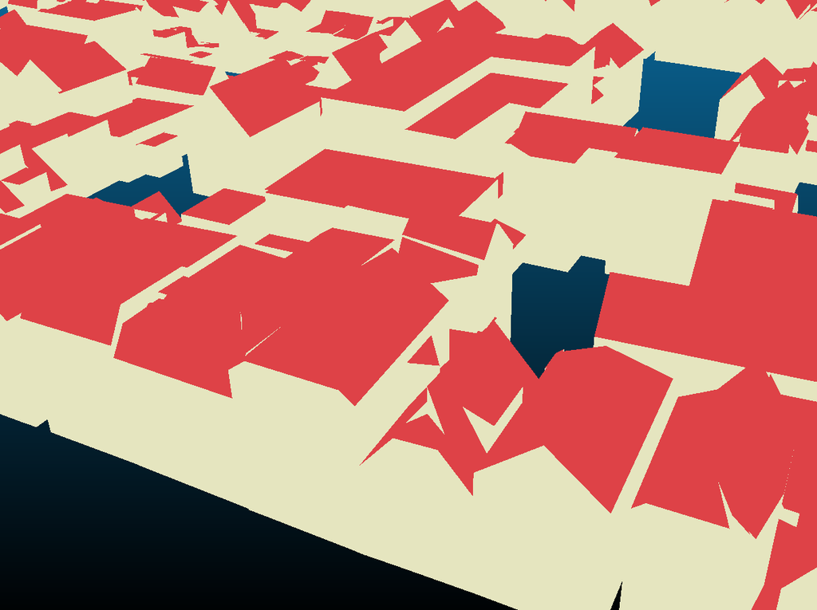

LoD 2.2 buildings from the 3DBAG.

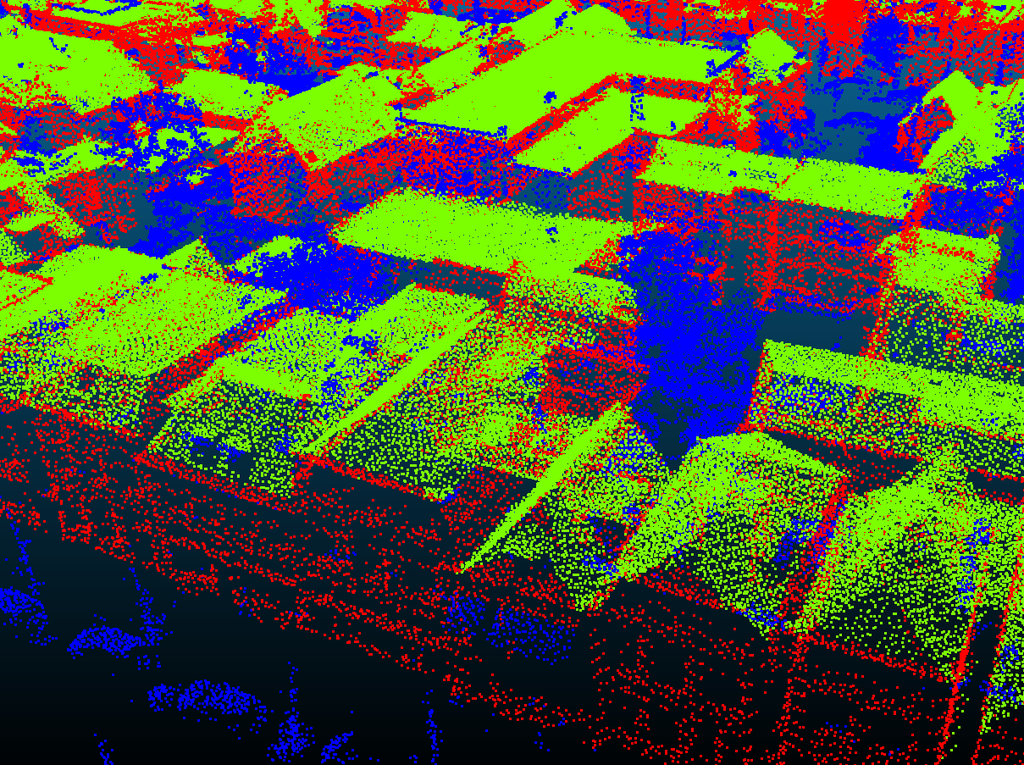

The classification of the points from AHN 4.

Figure 2: Example of classifying the AHN 4 with the 3DBAG.

## Roofprints

- The method still needs to be determined
- It will depend on the results of semantic segmentation

## Footprints

- Sweep vertical planes parallel to the roofprint edges
- Identify the best one or none at all
- Potential to use symmetry of roofs

## Assessment

- Create a fake ground-truth dataset:
  - Create a fake LoD 2.3 dataset from 3DBAG LoD 2.2 by randomly extending the roof planes
  - Simulate an ALS point cloud with tools such as [HELIOS++](https://github.com/3dgeo-heidelberg/helios)
- Evaluate the method on this dataset
- Some annotations of real data for better assessment?

# Current and future work

## Until now

- Literature review
- Explored French and Dutch datasets and their metadata
- Started the work on classifying AHN 4 using 3DBAG

## From now on

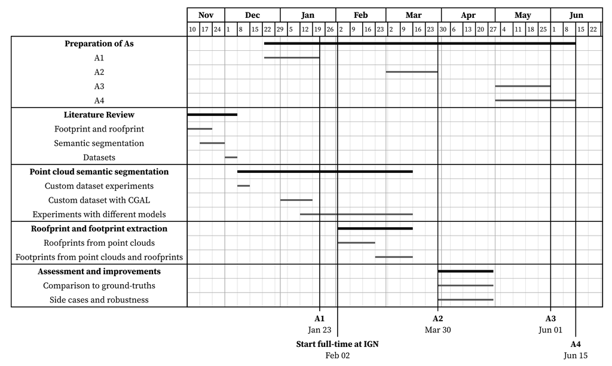

Project planning

## Thank you.

## References

Biasutti, P., Bugeau, A., Aujol, J.-F., & Brédif, M. (2019). *RIU-net: Embarrassingly simple semantic segmentation of 3D LiDAR point cloud*. https://doi.org/10.48550/ARXIV.1905.08748

Biljecki, F., Ledoux, H., & Stoter, J. (2016). An improved LOD specification for 3D building models. *Computers, Environment and Urban Systems*, *59*, 25–37. https://doi.org/10.1016/j.compenvurbsys.2016.04.005

Cramer, M. (2010). The DGPF-test on digital airborne camera evaluation overview and test design. *Photogrammetrie - Fernerkundung - Geoinformation*, *2010*(2), 73–82. https://doi.org/10.1127/1432-8364/2010/0041

Dahlke, D., Linkiewicz, M., & Meissner, H. (2015). True 3D building reconstruction: Façade, roof and overhang modelling from oblique and vertical aerial imagery. *International Journal of Image and Data Fusion*, *6*(4), 314–329. https://doi.org/10.1080/19479832.2015.1071287

Frommholz, D., Linkiewicz, M., Meissner, H., & Dahlke, D. (2017). Reconstructing buildings with discontinuities and roof overhangs from oblique aerial imagery. *The International Archives of the Photogrammetry, Remote Sensing and Spatial Information Sciences*, *XLII-1/W1*, 465–471. https://doi.org/10.5194/isprs-archives-xlii-1-w1-465-2017

Gaydon, C., Daab, M., & Roche, F. (2024). *FRACTAL: An ultra-large-scale aerial lidar dataset for 3D semantic segmentation of diverse landscapes*. https://doi.org/10.48550/ARXIV.2405.04634

Goebbels, S., & Pohle-Fröhlich, R. (2023). Automatic reconstruction of roof overhangs for 3D city models. *Proceedings of the 18th International Joint Conference on Computer Vision, Imaging and Computer Graphics Theory and Applications*, 145–152. https://doi.org/10.5220/0011604200003417

Hu, Q., Yang, B., Khalid, S., Xiao, W., Trigoni, N., & Markham, A. (2020). *Towards semantic segmentation of urban-scale 3D point clouds: A dataset, benchmarks and challenges*. https://doi.org/10.48550/ARXIV.2009.03137

Kölle, M., Laupheimer, D., Schmohl, S., Haala, N., Rottensteiner, F., Wegner, J. D., & Ledoux, H. (2021). The hessigheim 3D (H3D) benchmark on semantic segmentation of high-resolution 3D point clouds and textured meshes from UAV LiDAR and multi-view-stereo. *ISPRS Open Journal of Photogrammetry and Remote Sensing*, *1*, 100001. https://doi.org/10.1016/j.ophoto.2021.100001

Li, M., Lin, S., Wang, Z., Shen, Y., Zhang, B., & Ma, L. (2024). Class-imbalanced semi-supervised learning for large-scale point cloud semantic segmentation via decoupling optimization. *Pattern Recognition*, *156*, 110701. https://doi.org/10.1016/j.patcog.2024.110701

Li, W., Wang, F.-D., & Xia, G.-S. (2020). A geometry-attentional network for ALS point cloud classification. *ISPRS Journal of Photogrammetry and Remote Sensing*, *164*, 26–40. https://doi.org/10.1016/j.isprsjprs.2020.03.016

Li, X., Li, C., Tong, Z., Lim, A., Yuan, J., Wu, Y., Tang, J., & Huang, R. (2020). Campus3D: A photogrammetry point cloud benchmark for hierarchical understanding of outdoor scene. *Proceedings of the 28th ACM International Conference on Multimedia*, 238–246. https://doi.org/10.1145/3394171.3413661

Niemeyer, J., Rottensteiner, F., & Soergel, U. (2014). Contextual classification of lidar data and building object detection in urban areas. *ISPRS Journal of Photogrammetry and Remote Sensing*, *87*, 152–165. https://doi.org/10.1016/j.isprsjprs.2013.11.001

Pan, Z., Zhang, N., Gao, W., Liu, S., & Li, G. (2025). Point cloud semantic segmentation with sparse and inhomogeneous annotations. *Proceedings of the AAAI Conference on Artificial Intelligence*, *39*(6), 6354–6362. https://doi.org/10.1609/aaai.v39i6.32680

Panday, U. S., & Gerke, M. (2012). Fitting of parametric building models to oblique aerial images. *The International Archives of the Photogrammetry, Remote Sensing and Spatial Information Sciences*, *XXXVIII-4/W19*, 233–238. https://doi.org/10.5194/isprsarchives-xxxviii-4-w19-233-2011

Thomas, H., Qi, C. R., Deschaud, J.-E., Marcotegui, B., Goulette, F., & Guibas, L. J. (2019). *KPConv: Flexible and deformable convolution for point clouds*. https://doi.org/10.48550/ARXIV.1904.08889

Varney, N., Asari, V. K., & Graehling, Q. (2020). *DALES: A large-scale aerial LiDAR data set for semantic segmentation*. https://doi.org/10.48550/ARXIV.2004.11985

Vijaywargiya, J., & Ramiya, A. M. (2025). Thiruvananthapuram aerial LiDAR dataset (TALD): A benchmark for complex urban point cloud. *IEEE Access*, *13*, 42350–42363. https://doi.org/10.1109/access.2025.3546628

Wu, X., Jiang, L., Wang, P.-S., Liu, Z., Liu, X., Qiao, Y., Ouyang, W., He, T., & Zhao, H. (2023). *Point transformer V3: Simpler, faster, stronger*. https://doi.org/10.48550/ARXIV.2312.10035

Xu, C., Wu, B., Wang, Z., Zhan, W., Vajda, P., Keutzer, K., & Tomizuka, M. (2020). *SqueezeSegV3: Spatially-adaptive convolution for efficient point-cloud segmentation*. https://doi.org/10.48550/ARXIV.2004.01803

Ye, Z., Xu, Y., Huang, R., Tong, X., Li, X., Liu, X., Luan, K., Hoegner, L., & Stilla, U. (2020). LASDU: A large-scale aerial LiDAR dataset for semantic labeling in dense urban areas. *ISPRS International Journal of Geo-Information*, *9*(7), 450. https://doi.org/10.3390/ijgi9070450

Zachar, P., Bakuła, K., & Ostrowski, W. (2023). CENAGIS-ALS benchmark - new proposal for dense ALS benchmark based on the review of datasets and benchmarks for 3D point cloud segmentation. *The International Archives of the Photogrammetry, Remote Sensing and Spatial Information Sciences*, *XLVIII-1/W3-2023*, 227–234. https://doi.org/10.5194/isprs-archives-xlviii-1-w3-2023-227-2023

Zhao, H., Jiang, L., Jia, J., Torr, P., & Koltun, V. (2020). *Point transformer*. https://doi.org/10.48550/ARXIV.2012.09164

Zolanvari, I., Ruano, S., Rana, A., Cummins, A., Smolic, A., Da Silva, R., & Rahbar, M. (2019, September). *DublinCity: Annotated LiDAR point cloud and its applications*.